# 统计软件第4次作业

请各位同学于2022年11月27日24点前将作业上传到课堂派

1、请将你的html文件命名为：姓名_学号_统计软件第4次作业。

2、展示你的代码、输出结果和相应的注释

3、凡迟交或不交作业或命名不正确的，本次作业将有相应扣分。

案例背景：随着我国在线旅行行业的迅速发展，“来一场说走就走的旅行”终于不只是美好的憧憬，“互联网+旅游”让我们足不出户就能通过在线旅游平台上规划好旅程、预定好出行产品。同时，伴随着新一轮消费升级的浪潮，人们对旅游产品的个性化需求和品质有了更高的标准，而在线旅游透明的价格、丰富的产品、真实的评论为游客带来了切实的便利。

据统计，2016年在线旅游交易规模突破6000亿，增速超过30%，预计2017年仍将保持稳定的速度增长。市场的高速发展期也带来了在线旅游平台竞争的白热化，如何提升产品品质和用户体验成为能否长期生存的关键。

数据介绍：案例数据“BearTrip.csv”提供了4366条已经过预处理的在线旅游产品信息，可用于描述分析和回归分析。共27个变量，其中包括：近3个月产品成交量（threemonth），顾客满意度（satisfactory），旅行社评分（storerating），旅行社信用等级（creditLevel），旅游地区（type），行程天数（tripschedule），景点个数（num_spot），价格等级（price.level），旅游类型（title.type），项目档次（title.level），酒店档次（combo.level），交通类型（飞机plane、高铁CRH、火车train、大巴coach），优惠活动信息（礼品卡giftcard、多人立减teamdiscount、优惠信息discount、早订优惠earlydiscount、会员价vipdiscount），服务保障信息（出行保障trip_guarantee_1、铁定成团trip_guarantee_2、无自费no_self_financed、无购物no_forced_shopping、如实描述describes、随时退refund），以及旅行社知名度（hot_names）等。

## 任务一：

读入数据，查看数据的样本量，查看数据概况。

```
## [1] 4366
```

```
##    threemonth     satisfactory        storerating     creditLevel
##  Min.   :  0.00   Length:4366        Min.   :4.800   Min.   :0.000
##  1st Qu.: 23.00   Class :character   1st Qu.:5.000   1st Qu.:0.000
##  Median : 26.00   Mode  :character   Median :5.000   Median :2.000
##  Mean   : 29.56                      Mean   :4.993   Mean   :2.099
##  3rd Qu.: 29.00                      3rd Qu.:5.000   3rd Qu.:4.000
##  Max.   :946.00                      Max.   :5.000   Max.   :5.000
##      type           tripschedule         num_spot         price.level
##  Length:4366        Length:4366        Length:4366        Length:4366
##  Class :character   Class :character   Class :character   Class :character
##  Mode  :character   Mode  :character   Mode  :character   Mode  :character
##
##
##
##   title.type        title.level        combo.level          plane
##  Length:4366        Length:4366        Length:4366        Mode :logical
##  Class :character   Class :character   Class :character   FALSE:1784
##  Mode  :character   Mode  :character   Mode  :character   TRUE :2582
##
##
##
##     CRH            train           coach          giftcard
##  Mode :logical   Mode :logical   Mode :logical   Mode :logical
##  FALSE:4307      FALSE:4305      FALSE:3187      FALSE:203
##  TRUE :59        TRUE :61        TRUE :1179      TRUE :4163
##
##
##
##  teamdiscount     discount       earlydiscount   vipdiscount
##  Mode :logical   Mode :logical   Mode :logical   Mode :logical
##  FALSE:4342      FALSE:4343      FALSE:4352      FALSE:4346
##  TRUE :24        TRUE :23        TRUE :14        TRUE :20
##
##
##
##  trip_guarantee_1 trip_guarantee_2 no_self_financed no_forced_shopping
##  Mode :logical    Mode :logical    Mode :logical    Mode :logical
##  FALSE:3907       FALSE:2308       FALSE:3351       FALSE:3038
##  TRUE :459        TRUE :2058       TRUE :1015       TRUE :1328
##
##
##
##  describes         refund         hot_names
##  Mode :logical   Mode :logical   Length:4366
##  FALSE:270       FALSE:1399      Class :character
##  TRUE :4096      TRUE :2967      Mode  :character
##
##
##
```

## 任务二：

绘制各旅游地区（type）的平均成交量柱状图，并依平均成交量降序排列。对各旅游地区的成交量柱状图作出简要解读。

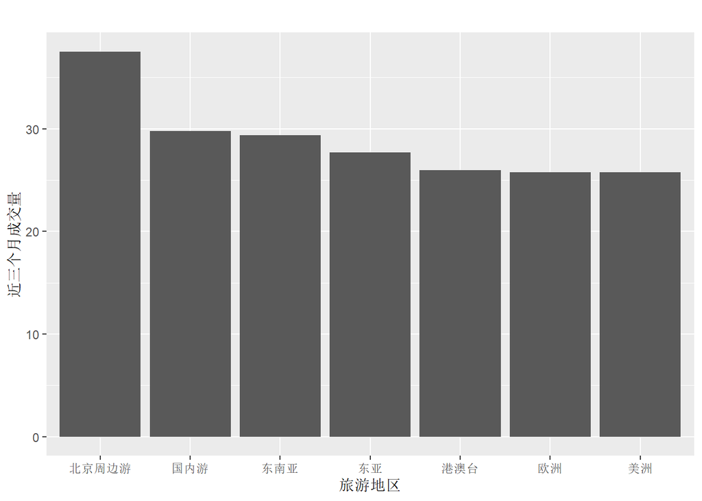

## 任务三：

分别计算优惠信息（discount）、早订优惠（earlydiscount）、多人立减（teamdiscount）、会员价（vipdiscount）、礼品卡（giftcard）等五种优惠活动下，参加或不参加优惠活动的平均成交量，并绘制不同优惠活动信息下平均成交量的分组柱状图。对成交量的分组柱状图作出简要解读。 提示：apply()函数可以一次对多行或多列数据执行同种运算；tapply()函数可以依据某一变量的不同取值，对另一变量执行分组运算。

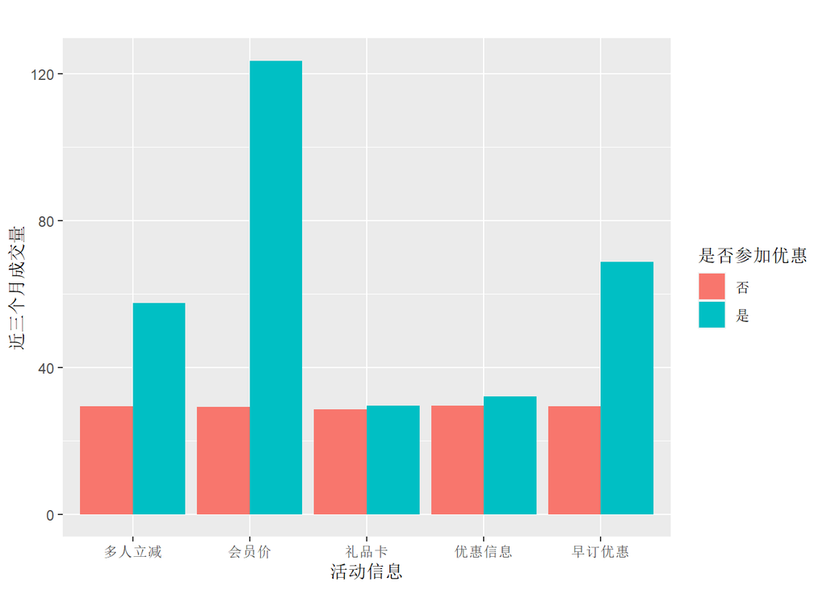

## 任务四：

以近3个月成交量（threemonth）的对数为因变量，并以AIC准则进行变量选择，建立多元线性回归模型，查看建模结果并作出简要解读。

对分类变量设置统一的基准组如下（其他取值水平可以自定义排序）：

酒店档次以经济型为基准组； 项目档次以普通为基准组； 旅游类型以跟团游为基准组； 旅行社知名度以普通为基准组； 旅行社信用等级以1为基准组； 注意：由于因变量threemonth的取值中有0，因此作对数变换前可以先对该变量的所有取值+1。

提示：解读回归模型时，应对模型整体的拟合优度（R方）、显著性（F检验）、各变量系数的值及其显著性（t检验）依次进行解释。

## 任务五：

采取5折交叉验证法对模型的外样本预测精度进行评价，并给出你的结论。